# Assignment 12

Gina Catellier

10/12/2020

1. Install the package `mlbench` and use the follows to import the data

```r
library(mlbench)
data(PimaIndiansDiabetes)
df <- PimaIndiansDiabetes
```

- Set seed to be 2020.
- The target variable is `diabetes`
- Partition the data into 80% training and 20% testing.

```r
library(caret)
set.seed(2020)

names(df)[9] <- 'target'
splitIndex <- createDataPartition(df$target, p = .80,
                                  list = FALSE)
df_train <- df[ splitIndex,]
df_test <- df[-splitIndex,]
```

2. Use cross-validation of 30 folds to tune random forest (method=‘rf’). What is the `mtry` value that produces the greatest accuracy?

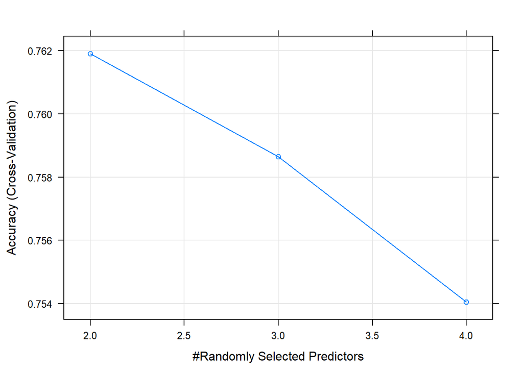

```r
tuneGrid = expand.grid(mtry = 2:4)

trControl = trainControl(method = "cv",
                         number = 30)

forest_cv <- train(target~., data=df_train,
                                method = "rf",
                                trControl = trControl,
                                tuneGrid = tuneGrid)

plot(forest_cv)
```

The ‘mtry’ value of 2 produces the greatest accuracy.

3. Use cross-validation with of 30 folds to tune random forest (method=‘ranger’). What are the parameters that produce the greatest accuracy?

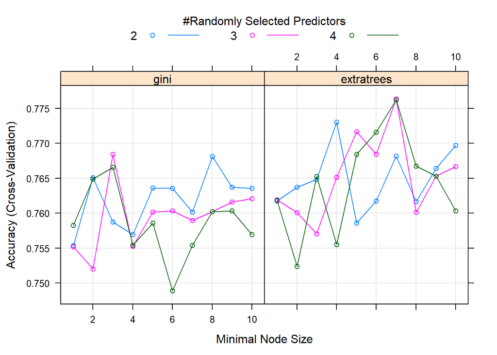

```r
tuneGrid = expand.grid(mtry = 2:4,
                       splitrule = c('gini', 'extratrees'),
                       min.node.size = c(1:10))

ranger_cv <- train(target~., data=df_train,
                                method = "ranger",
                                trControl = trControl,
                                tuneGrid = tuneGrid)

plot(ranger_cv)
```

The parameters that produce the greatest accuracy are 3 predictors, with extratrees at 7.

4. Go to https://topepo.github.io/caret/available-models.html and pick a classification model. Tune the classification model using cross-validation of 30 folds.

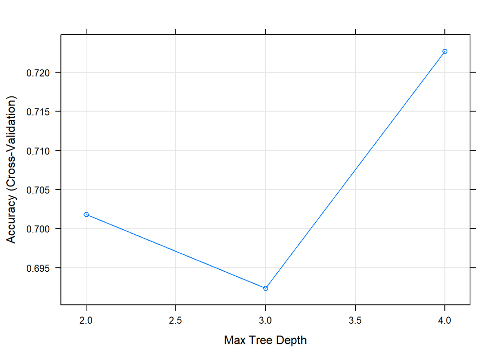

```r
tuneGrid = expand.grid(maxdepth = 2:4, iter=3, nu=2)

trees_cv <- train(target~., data=df_train,
                                method = "ada",
                                trControl = trControl,
                                tuneGrid = tuneGrid)

plot(trees_cv)
```

I used Boosted Classification Trees (‘ada’), which shows the greatest accuracy is with a max depth of 4.

5. Compare the three models in question 2, 3, and 4 to select the final model. Evaluate the accuracy of the final model on the test data.

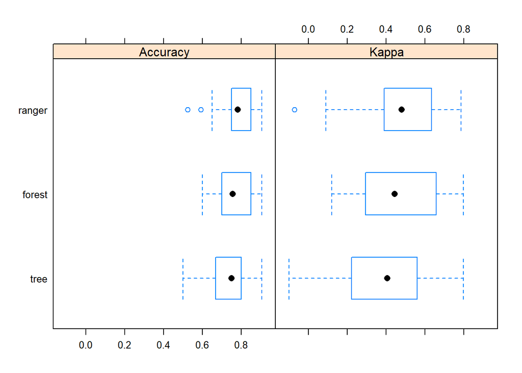

```r
results <- resamples(list(forest = forest_cv,
                          ranger = ranger_cv,
                          tree= trees_cv))
bwplot(results)
```

```r
pred <- predict(ranger_cv, df_test)
cm <- confusionMatrix(data = pred, reference = df_test$target, positive = "pos")
cm$overall[1]
```

```
##  Accuracy
## 0.7777778
```

The final model would be ranger, which has an accuracy of 0.7777778.